# Exploring Soil Taxonomy I

D.E. Beaudette

2019-07-22

## A Simple Example

Question: *“how common is the ‘frag’ formative element at the subgroup level of Soil Taxonomy?”*.

Not that common, as of FY2019:

- 4,434,873 acres mapped
- 391,543 delineations
- 43 families
- 57 series

### Annotated Code / Discussion

Load required packages. `{SoilTaxonomy}` is availble via [GitHub](https://github.com/ncss-tech/SoilTaxonomy/tree/master/R_pkg).

```r
library(data.tree)
library(igraph)
library(SoilTaxonomy)
library(plyr)
```

Get the current Soil Classification database snapshot, c/o SoilWeb.

```r
tf <- tempfile()
download.file('https://github.com/ncss-tech/SoilTaxonomy/raw/master/databases/SC-database.csv.gz', destfile = tf)
SC <- read.csv(gzfile(tf), stringsAsFactors = FALSE)

# keep specific columns
SC <- SC[, c('soilseriesname', 'taxclname', 'tax_grtgroup', 'tax_subgrp')]

# re-name and normalize
names(SC) <- c('series', 'family', 'tax_greatgroup', 'tax_subgroup')
SC$tax_subgroup <- tolower(SC$tax_subgroup)
```

Get the current subgroup acreage database snapshot, derived from SSURGO, c/o SoilWeb.

```r
tf <- tempfile()
download.file('https://github.com/ncss-tech/SoilTaxonomy/raw/master/databases/taxsubgrp-stats.txt.gz', destfile = tf)
sg.ac <- read.table(gzfile(tf), header = FALSE, stringsAsFactors = FALSE, sep='|')
names(sg.ac) <- c('tax_subgroup', 'ac', 'n_polygons')

# normalize names
sg.ac$tax_subgroup <- tolower(sg.ac$tax_subgroup)
```

Load the current edition of Soil Taxonomy, hierarchy to the subgroup level. This is part of the `{SoilTaxonomy}` package.

```r
# ST to the subgroup level
data(ST)

# tabulate number of series / family per subgroup
series.stats <- ddply(SC, 'tax_subgroup', .fun=summarize, n_series=length(unique(series)), n_family=length(unique(family)))
```

Combine data sources and replace NA with 0.

```r
# join {ST} to {acreage by subgroup}
ST <- merge(ST, sg.ac, by='tax_subgroup', all.x=TRUE)

# join {ST + subgroup acreage} to {series stats}
ST <- merge(ST, series.stats, by='tax_subgroup', all.x=TRUE)

# set NA acreage, n_series, n_family to 0
ST$ac[which(is.na(ST$ac))] <- 0
ST$n_polygons[which(is.na(ST$n_polygons))] <- 0
ST$n_series[which(is.na(ST$n_series))] <- 0
ST$n_family[which(is.na(ST$n_family))] <- 0
```

Select taxa with *frag* in the subgroup label and initialize a [`data.tree` object](https://cran.r-project.org/web/packages/data.tree/vignettes/data.tree.html) to describe the hierarchy.

```r
# setup tree path, note that there has to be a "parent" level that sits above orders
ST$pathString <- paste('ST', ST$tax_order, ST$tax_suborder, ST$tax_greatgroup, ST$tax_subgroup, sep='/')

# index to 'frag' at GG level
gg.idx <- grep('frag', ST$tax_greatgroup, ignore.case = TRUE)

# index to 'frag' at SG level
sg.idx <- grep('frag', ST$tax_subgroup, ignore.case = TRUE)

# exclude 'frag' at the GG level
idx <- setdiff(sg.idx, gg.idx)

# convert selected taxa to data.tree object
f.sg <- as.Node(ST[idx, ])
```

Modfy the hierachy by creating running sums of area, number of delineations, number of soil series, and number of family taxa. Sort the hierarcy by area.

```r
# tabulate acreage, polygons, num series, num families
f.sg$Do(function(node) node$ac <- Aggregate(node, attribute = "ac", aggFun = sum), traversal = "post-order")

f.sg$Do(function(node) node$n_polygons <- Aggregate(node, attribute = "n_polygons", aggFun = sum), traversal = "post-order")

f.sg$Do(function(node) node$n_series <- Aggregate(node, attribute = "n_series", aggFun = sum), traversal = "post-order")

f.sg$Do(function(node) node$n_family <- Aggregate(node, attribute = "n_family", aggFun = sum), traversal = "post-order")

# sort by acreage
Sort(f.sg, attribute = 'ac', decreasing = TRUE, recursive = TRUE)
```

Results. Subgroup taxa without any associated soil series are defined in the Keys but have not (yet) been mapped in the detailed soil survey (SSURGO).

```r
print(f.sg, 'ac', 'n_family', 'n_series')
```

```
                                    levelName      ac n_family n_series
1  ST                                         4434873       43       57
2   ¦--alfisols                               2878426       27       31
3   ¦   ¦--aqualfs                            1483503        5        6
4   ¦   ¦   ¦--epiaqualfs                     1115786        3        4
5   ¦   ¦   ¦   ¦--aeric fragic epiaqualfs    1054806        2        3
6   ¦   ¦   ¦   °--fragic epiaqualfs            60980        1        1
7   ¦   ¦   ¦--glossaqualfs                    367717        2        2
8   ¦   ¦   ¦   ¦--fragic glossaqualfs         199855        1        1
9   ¦   ¦   ¦   °--aeric fragic glossaqualfs   167862        1        1
10  ¦   ¦   °--endoaqualfs                          0        0        0
11  ¦   ¦       ¦--aeric fragic endoaqualfs         0        0        0
12  ¦   ¦       °--fragic endoaqualfs               0        0        0
13  ¦   ¦--udalfs                             1392142       21       24
14  ¦   ¦   ¦--hapludalfs                      997342       11       14
```

[output cut: 58 more lines]

Graphical representation, symbol size is proportional to areal extent.

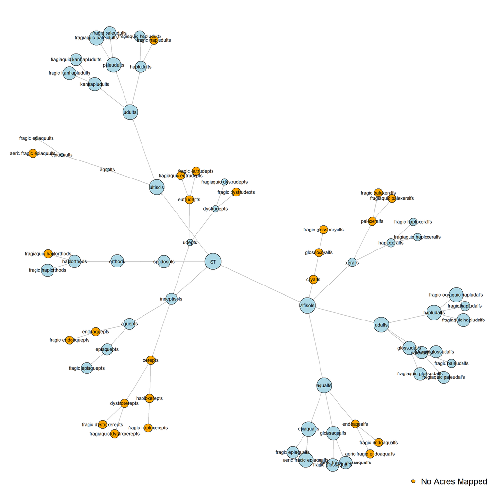

```r
# convert data.tree to igraph object
g <- as.igraph(f.sg, directed = TRUE, direction = "climb", vertexAttributes='ac')

# extract area
v.ac <- V(g)$ac

# representat area with vertex size and color
V(g)$size <- ifelse(v.ac == 0, 4, log(sqrt(v.ac)))
V(g)$color <- ifelse(v.ac == 0, 'orange', 'lightblue')

par(mar=c(1,1,1,1))
plot(g, edge.arrow.size=0.15, vertex.label.cex=0.85, layout=layout_with_fr, vertex.label.family='sans', vertex.label.color='black')

legend('bottomright', legend=c('No Acres Mapped'), pch=21, pt.bg='orange', bty='n', cex=1.5)
```

To be continued.

This document is based on `SoilTaxonomy` version 0.0.0.9000.